## Introduction

The project is on a data set that includes information about various body sensor measurements and the performance of an exercise. 6 participants were asked to perform one exercise in five different ways, only one of which was correct. The data is taken from the following:

Velloso, E.; Bulling, A.; Gellersen, H.; Ugulino, W.; Fuks, H. Qualitative Activity Recognition of Weight Lifting Exercises. Proceedings of 4th International Conference in Cooperation with SIGCHI (Augmented Human ’13) . Stuttgart, Germany: ACM SIGCHI, 2013.

Read more about the data at http://groupware.les.inf.puc-rio.br/har#ixzz3yKhLl6bz

The goal of the project is to build a good predictor for the classification of the exercise into the five categories.The original data set (pml-training.csv) has 19622 observations for 160 variables. Many of the variables contain little or not information, utltimately only about 50 variables will be used. However, the number of the variables is still relatively large. Also, interpretability is not the goal here, only predictive power. Finally, the aim is to classify several (more than two) categories. Thus, some forms of machine learning are either not feasible or impractical (e.g., logistic regression, naive Bayes). In general, ensemble methods perform well when it comes to predictions. Thus, the strategy will be to compute a decision tree first as a baseline model and to fit random forest models next. If the predictive power of random forest models is sufficient (classification error of less than 15%) the search would stop, otherwise other models (e.g., boosting, stacking predictors) will be considered.

## Pre-processing

The data set contains 160 variables, however several are not relevant for the predictive tasks (e.g., observation ID, time stamp) and others do not contain much observation.

As a quick look at the data shows, many variables have a large number of missing values.

```
##   X user_name raw_timestamp_part_1 raw_timestamp_part_2   cvtd_timestamp
## 1 1  carlitos           1323084231               788290 05/12/2011 11:23
## 2 2  carlitos           1323084231               808298 05/12/2011 11:23
## 3 3  carlitos           1323084231               820366 05/12/2011 11:23
## 4 4  carlitos           1323084232               120339 05/12/2011 11:23
## 5 5  carlitos           1323084232               196328 05/12/2011 11:23
## 6 6  carlitos           1323084232               304277 05/12/2011 11:23
##   new_window num_window roll_belt pitch_belt yaw_belt total_accel_belt
## 1         no         11      1.41       8.07    -94.4                3
## 2         no         11      1.41       8.07    -94.4                3
## 3         no         11      1.42       8.07    -94.4                3
## 4         no         12      1.48       8.05    -94.4                3
## 5         no         12      1.48       8.07    -94.4                3
## 6         no         12      1.45       8.06    -94.4                3
##   kurtosis_roll_belt kurtosis_picth_belt kurtosis_yaw_belt
```

[output cut: 265 more lines]

[output not shown]

[output cut: 313 more lines]

```
##  Min.   :-446.00   Min.   :-1280.0   Min.   :-896.0   Min.   :-973.0
##  1st Qu.:-182.00   1st Qu.: -616.0   1st Qu.:   2.0   1st Qu.: 191.0
##  Median : -39.00   Median : -378.0   Median : 591.0   Median : 511.0
##  Mean   : -55.29   Mean   : -312.6   Mean   : 380.1   Mean   : 393.6
##  3rd Qu.:  26.00   3rd Qu.:  -73.0   3rd Qu.: 737.0   3rd Qu.: 653.0
##  Max.   : 291.00   Max.   :  672.0   Max.   :1480.0   Max.   :1090.0
##
##  classe
##  A:5580
##  B:3797
##  C:3422
##  D:3216
##  E:3607
##
##
```

```r
str(training)
```

[output not shown]

[output cut: 86 more lines]

The data is pre-processed by removing irrelevant variables and deleting variables with very low variance. In addition, variables with 25% or more of missing data are removed from the data set.

```r
## Cleaning data
# removing irrelevant variables (observation ID, time stamps, internal info)
dim(training)
```

```
## [1] 19622   160
```

```r
training<-subset(training, select=-c(X, raw_timestamp_part_1, raw_timestamp_part_2, cvtd_timestamp, new_window, num_window))
dim(training)
```

```
## [1] 19622   154
```

```r
# Removing variables with nearly no variance
NZVvariables<-nearZeroVar(training)
training<-training[, -NZVvariables]
dim(training)
```

```
## [1] 19622    95
```

```r
# Removing variables with more than 25% missing values
training<-training[, colMeans(is.na(training))<.25]
dim(training)
```

```
## [1] 19622    54
```

```r
summary(training)
```

```
##     user_name      roll_belt        pitch_belt          yaw_belt
##  adelmo  :3892   Min.   :-28.90   Min.   :-55.8000   Min.   :-180.00
##  carlitos:3112   1st Qu.:  1.10   1st Qu.:  1.7600   1st Qu.: -88.30
##  charles :3536   Median :113.00   Median :  5.2800   Median : -13.00
##  eurico  :3070   Mean   : 64.41   Mean   :  0.3053   Mean   : -11.21
##  jeremy  :3402   3rd Qu.:123.00   3rd Qu.: 14.9000   3rd Qu.:  12.90
##  pedro   :2610   Max.   :162.00   Max.   : 60.3000   Max.   : 179.00
##  total_accel_belt  gyros_belt_x        gyros_belt_y       gyros_belt_z
##  Min.   : 0.00    Min.   :-1.040000   Min.   :-0.64000   Min.   :-1.4600
##  1st Qu.: 3.00    1st Qu.:-0.030000   1st Qu.: 0.00000   1st Qu.:-0.2000
##  Median :17.00    Median : 0.030000   Median : 0.02000   Median :-0.1000
##  Mean   :11.31    Mean   :-0.005592   Mean   : 0.03959   Mean   :-0.1305
##  3rd Qu.:18.00    3rd Qu.: 0.110000   3rd Qu.: 0.11000   3rd Qu.:-0.0200
##  Max.   :29.00    Max.   : 2.220000   Max.   : 0.64000   Max.   : 1.6200
##   accel_belt_x       accel_belt_y     accel_belt_z     magnet_belt_x
##  Min.   :-120.000   Min.   :-69.00   Min.   :-275.00   Min.   :-52.0
##  1st Qu.: -21.000   1st Qu.:  3.00   1st Qu.:-162.00   1st Qu.:  9.0
##  Median : -15.000   Median : 35.00   Median :-152.00   Median : 35.0
##  Mean   :  -5.595   Mean   : 30.15   Mean   : -72.59   Mean   : 55.6
##  3rd Qu.:  -5.000   3rd Qu.: 61.00   3rd Qu.:  27.00   3rd Qu.: 59.0
##  Max.   :  85.000   Max.   :164.00   Max.   : 105.00   Max.   :485.0
##  magnet_belt_y   magnet_belt_z       roll_arm         pitch_arm
##  Min.   :354.0   Min.   :-623.0   Min.   :-180.00   Min.   :-88.800
##  1st Qu.:581.0   1st Qu.:-375.0   1st Qu.: -31.77   1st Qu.:-25.900
##  Median :601.0   Median :-320.0   Median :   0.00   Median :  0.000
##  Mean   :593.7   Mean   :-345.5   Mean   :  17.83   Mean   : -4.612
##  3rd Qu.:610.0   3rd Qu.:-306.0   3rd Qu.:  77.30   3rd Qu.: 11.200
##  Max.   :673.0   Max.   : 293.0   Max.   : 180.00   Max.   : 88.500
##     yaw_arm          total_accel_arm  gyros_arm_x        gyros_arm_y
##  Min.   :-180.0000   Min.   : 1.00   Min.   :-6.37000   Min.   :-3.4400
##  1st Qu.: -43.1000   1st Qu.:17.00   1st Qu.:-1.33000   1st Qu.:-0.8000
##  Median :   0.0000   Median :27.00   Median : 0.08000   Median :-0.2400
##  Mean   :  -0.6188   Mean   :25.51   Mean   : 0.04277   Mean   :-0.2571
##  3rd Qu.:  45.8750   3rd Qu.:33.00   3rd Qu.: 1.57000   3rd Qu.: 0.1400
##  Max.   : 180.0000   Max.   :66.00   Max.   : 4.87000   Max.   : 2.8400
##   gyros_arm_z       accel_arm_x       accel_arm_y      accel_arm_z
##  Min.   :-2.3300   Min.   :-404.00   Min.   :-318.0   Min.   :-636.00
##  1st Qu.:-0.0700   1st Qu.:-242.00   1st Qu.: -54.0   1st Qu.:-143.00
##  Median : 0.2300   Median : -44.00   Median :  14.0   Median : -47.00
##  Mean   : 0.2695   Mean   : -60.24   Mean   :  32.6   Mean   : -71.25
```

[output cut: 50 more lines]

```
##  Max.   :311.00000   Max.   :231.0000   Max.   : 477.00   Max.   : 923.0
##  accel_forearm_z   magnet_forearm_x  magnet_forearm_y magnet_forearm_z
##  Min.   :-446.00   Min.   :-1280.0   Min.   :-896.0   Min.   :-973.0
##  1st Qu.:-182.00   1st Qu.: -616.0   1st Qu.:   2.0   1st Qu.: 191.0
##  Median : -39.00   Median : -378.0   Median : 591.0   Median : 511.0
##  Mean   : -55.29   Mean   : -312.6   Mean   : 380.1   Mean   : 393.6
##  3rd Qu.:  26.00   3rd Qu.:  -73.0   3rd Qu.: 737.0   3rd Qu.: 653.0
##  Max.   : 291.00   Max.   :  672.0   Max.   :1480.0   Max.   :1090.0
##  classe
##  A:5580
##  B:3797
##  C:3422
##  D:3216
##  E:3607
##
```

This leaves 53 predictor variables. The outcome (classe) is relatively balanced (except for class A). Next, the data is split into a training (75% or 14 718 observations) and test (25% or 4 904 observations) data set.

```r
## Create seperate data frames (testing.df, training.df, training.complete, validation)
# Split into training and testing data frames to build model
train<-createDataPartition(y=training$classe, p=.75, list=F)
training.df<-training[train, ]
testing.df<-training[-train, ]
dim(training.df)
```

```
## [1] 14718    54
```

```r
dim(testing.df)
```

```
## [1] 4904   54
```

```r
actual<-testing.df$classe
training.complete<-training
rm(training)
```

## Baseline model: a single decision tree

As a baseline model, a single decision tree is computed.

```r
## Fitting a single Tree
mod.tree<-train(classe~., method="rpart", data=training.df)
print(mod.tree, digits=3)
```

```
## CART
##
## 14718 samples
##    53 predictor
##     5 classes: 'A', 'B', 'C', 'D', 'E'
##
## No pre-processing
## Resampling: Bootstrapped (25 reps)
## Summary of sample sizes: 14718, 14718, 14718, 14718, 14718, 14718, ...
## Resampling results across tuning parameters:
##
##   cp      Accuracy  Kappa   Accuracy SD  Kappa SD
##   0.0345  0.521     0.3818  0.0431       0.0680
##   0.0599  0.400     0.1842  0.0598       0.0980
##   0.1154  0.335     0.0786  0.0400       0.0602
##
## Accuracy was used to select the optimal model using  the largest value.
## The final value used for the model was cp = 0.0345.
```

```r
print(mod.tree$finalModel)
```

```
## n= 14718
##
## node), split, n, loss, yval, (yprob)
##       * denotes terminal node
##
##  1) root 14718 10533 A (0.28 0.19 0.17 0.16 0.18)
##    2) roll_belt< 130.5 13483  9308 A (0.31 0.21 0.19 0.18 0.11)
##      4) pitch_forearm< -34.35 1163     4 A (1 0.0034 0 0 0) *
##      5) pitch_forearm>=-34.35 12320  9304 A (0.24 0.23 0.21 0.2 0.12)
##       10) magnet_dumbbell_y< 439.5 10462  7499 A (0.28 0.18 0.24 0.19 0.11)
##         20) roll_forearm< 123.5 6480  3837 A (0.41 0.18 0.18 0.17 0.06) *
##         21) roll_forearm>=123.5 3982  2663 C (0.08 0.18 0.33 0.22 0.18) *
##       11) magnet_dumbbell_y>=439.5 1858   912 B (0.029 0.51 0.041 0.23 0.19) *
##    3) roll_belt>=130.5 1235    10 E (0.0081 0 0 0 0.99) *
```

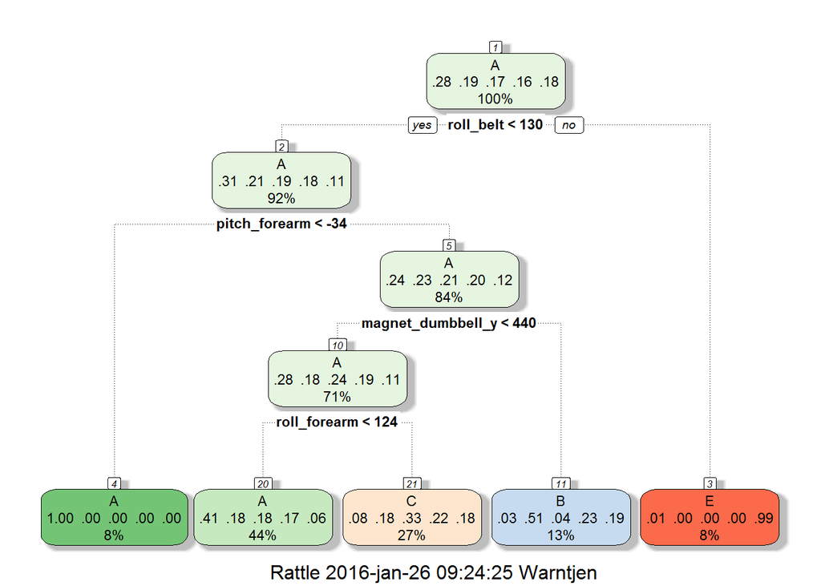

```r
fancyRpartPlot(mod.tree$finalModel)
```

The structure of the tree suggests a relatively straightforward prediction. Only a few variables were used and there seem to be no interaction effects. We can estimate the model’s out-of-sample performance by computing the accuracy for the testing data, which was not used in training the tree.

```r
# Using decision tree to predict testing data subset to estimate classification error
pred.tree.testing<-predict(mod.tree, newdata=testing.df)
actual.testing<-testing.df$classe
confusionMatrix(pred.tree.testing, actual.testing)
```

```
## Confusion Matrix and Statistics
##
##           Reference
## Prediction    A    B    C    D    E
##          A 1275  390  416  356  134
##          B   28  340   31  141  131
##          C   88  219  408  307  230
##          D    0    0    0    0    0
##          E    4    0    0    0  406
##
## Overall Statistics
##
##                Accuracy : 0.4953
##                  95% CI : (0.4812, 0.5094)
##     No Information Rate : 0.2845
##     P-Value [Acc > NIR] : < 2.2e-16
##
##                   Kappa : 0.3399
##  Mcnemar's Test P-Value : NA
##
## Statistics by Class:
##
##                      Class: A Class: B Class: C Class: D Class: E
## Sensitivity            0.9140  0.35827   0.4772   0.0000  0.45061
## Specificity            0.6307  0.91631   0.7916   1.0000  0.99900
## Pos Pred Value         0.4959  0.50671   0.3259      NaN  0.99024
## Neg Pred Value         0.9486  0.85613   0.8776   0.8361  0.88985
## Prevalence             0.2845  0.19352   0.1743   0.1639  0.18373
## Detection Rate         0.2600  0.06933   0.0832   0.0000  0.08279
## Detection Prevalence   0.5243  0.13683   0.2553   0.0000  0.08361
## Balanced Accuracy      0.7723  0.63729   0.6344   0.5000  0.72481
```

```r
1-confusionMatrix(pred.tree.testing, actual.testing)$overall['Accuracy']
```

```
## Accuracy
##  0.50469
```

The classification error rate (i.e., 1 minus the accuracy/correct prediction) is quite high. Given that there are five groups, it is substantially better than a random guess, but there is room for improvement. Thus, a random forest model is used next to improve the predictive power.

## Improving predictive power: fitting a random forest

To improve predictive power, a random forest with 2500 trees is computed. A larger number of trees (e.g. 5000) did not improve the accuracy of the prediction (not reported).

```r
## Random Forest
mod.rf<-randomForest(classe~., data=training.df, ntree=2500)
mod.rf
```

```
##
## Call:
##  randomForest(formula = classe ~ ., data = training.df, ntree = 2500)
##                Type of random forest: classification
##                      Number of trees: 2500
## No. of variables tried at each split: 7
##
##         OOB estimate of  error rate: 0.43%
## Confusion matrix:
##      A    B    C    D    E  class.error
## A 4182    2    0    0    1 0.0007168459
## B   14 2830    4    0    0 0.0063202247
## C    0   11 2553    3    0 0.0054538372
## D    0    0   17 2393    2 0.0078772803
## E    0    0    4    5 2697 0.0033259424
```

```r
# Random Forest (via caret)
# Takes too long to be practical (even with parallel processing)
#library(parallel)
#library(doParallel)
#cl <- makeCluster(4)
#registerDoParallel(cl)
#mod.rf<-train(classe~., data=training.df, method="rf", metric="Accuracy", trControl=trainControl(method = "cv", number = 5), prox=T,  preProcess=c("scale", "center"), allowParallel=T)
#print(mod.rf, digits=3)
#stopCluster(cl)
#registerDoSEQ()
```

Again, the classification error rate is estimated using the testing data to avoid an overestimate of the accuracy due to overfitting of the training data.

```r
# Using random forest model to predict testing data subset to estimate classification error
pred.rf.testing<-predict(mod.rf, newdata=testing.df)
actual.testing<-testing.df$classe
confusionMatrix(pred.rf.testing, actual.testing)
```

```
## Confusion Matrix and Statistics
##
##           Reference
## Prediction    A    B    C    D    E
##          A 1395    2    0    0    0
##          B    0  946    9    0    0
##          C    0    1  844    6    0
##          D    0    0    2  798    0
##          E    0    0    0    0  901
##
## Overall Statistics
##
##                Accuracy : 0.9959
##                  95% CI : (0.9937, 0.9975)
##     No Information Rate : 0.2845
##     P-Value [Acc > NIR] : < 2.2e-16
##
##                   Kappa : 0.9948
##  Mcnemar's Test P-Value : NA
##
## Statistics by Class:
##
##                      Class: A Class: B Class: C Class: D Class: E
## Sensitivity            1.0000   0.9968   0.9871   0.9925   1.0000
## Specificity            0.9994   0.9977   0.9983   0.9995   1.0000
## Pos Pred Value         0.9986   0.9906   0.9918   0.9975   1.0000
## Neg Pred Value         1.0000   0.9992   0.9973   0.9985   1.0000
## Prevalence             0.2845   0.1935   0.1743   0.1639   0.1837
## Detection Rate         0.2845   0.1929   0.1721   0.1627   0.1837
## Detection Prevalence   0.2849   0.1947   0.1735   0.1631   0.1837
## Balanced Accuracy      0.9997   0.9973   0.9927   0.9960   1.0000
```

```r
1-confusionMatrix(pred.rf.testing, actual.testing)$overall['Accuracy']
```

```
##    Accuracy
## 0.004078303
```

The random forest performs a lot better than the single decision tree. The prediction of the error rate based on out-of-bag predictions is less than 1%. Given this highly predictive model, the model building exercise can be stopped and we proceed to predict new data for the validation data set. Predicting the test data set also yields an estimated prediction error of less than 1%.

## Predicting new data: using the validation data

```r
## Predicting validation data
# Getting better predictions by using complete training data set to fit random forest model
mod.rf.complete<-randomForest(classe~., data=training.complete, ntree=2500)
mod.rf.complete
```

```
##
## Call:
##  randomForest(formula = classe ~ ., data = training.complete,      ntree = 2500)
##                Type of random forest: classification
##                      Number of trees: 2500
## No. of variables tried at each split: 7
##
##         OOB estimate of  error rate: 0.28%
## Confusion matrix:
##      A    B    C    D    E  class.error
## A 5578    1    0    0    1 0.0003584229
## B   11 3783    3    0    0 0.0036871214
## C    0   11 3410    1    0 0.0035067212
## D    0    0   20 3194    2 0.0068407960
## E    0    0    0    4 3603 0.0011089548
```

```r
# Making predictions
pred.rf.validation<-predict(mod.rf.complete, newdata=validation, type="class")
pred.rf.validation
```

```
##  1  2  3  4  5  6  7  8  9 10 11 12 13 14 15 16 17 18 19 20
##  B  A  B  A  A  E  D  B  A  A  B  C  B  A  E  E  A  B  B  B
## Levels: A B C D E
```